# Rethinking the Future of Agentic AI: A New Ecosystem

As AI continues to evolve, it's clear that the future is not just about making more capable agents. It’s about creating an ecosystem where agents, Sims, and Assistants work together seamlessly to provide more personalized, scalable, and trustworthy experiences for users. While many AI systems today focus on generative tasks like answering questions or providing recommendations and there's a need for something more sophisticated that goes beyond mere content generation.

Here's why I believe a new ecosystem—one that incorporates Agents, Sims, and Assistants—could be the key to the next age of AI. The ideas presented here are derived from the paper ["Agents Are Not Enough"](https://www.arxiv.org/pdf/2412.16241). This paper outlines the vision of an agentic AI ecosystem that integrates agents, Sims, and Assistants to provide a more powerful and cohesive user experience.

### Why Current AI Agents Fall Short

It’s easy to get excited about AI agents that can perform specific tasks like recommending movies or helping with simple searches. Many of these agents, especially those based on rule-based systems or symbolic logic (like Alexa or Siri), are still limited. They tend to operate in narrow, predefined environments and don’t generalize well to more complex or unfamiliar scenarios. (Still good statistical evidence is pending !!!)

Furthermore, there are significant challenges with scalability and communication. As the complexity of tasks increases, the computational resources required by these agents grow exponentially and they struggle to keep up. Multi-agent systems, may solve specific problems, but they still face significant hurdles when it comes to coordination, especially across a wide range of tasks.

### I think The Missing Pieces in the bigger picture is Sims and Assistants

I believe that to truly advance AI, we need to think about more than just standalone agents. To enable more human-like, efficient, and personalized interactions, we need to introduce **Sims** and **Assistants** into the mix.

- **Sims** are digital representations of users. These Sims aren’t just static profiles but dynamic models that capture a user’s preferences, behaviors, and contexts. They’re aware of the user’s environment, privacy settings, and the tasks at hand. Sims don’t just passively store data—they can act on behalf of the user, interacting with agents to perform tasks more effectively.
- **Assistants** can serve as the bridge between the user and the ecosystem of agents and Sims. A good Assistant doesn’t just perform tasks; it has a deep understanding of the user’s preferences and context, and it can proactively or reactively call upon the right Sims and agents to get things done. Think of Assistants as the personalized intelligent agents that can take on complex tasks without needing the user to step in at every turn.

### Building a Trustworthy and Scalable Ecosystem

This ecosystem—comprising agents, Sims, and Assistants—addresses some of the biggest challenges AI faces today. However, to make it truly work, we need to tackle a few key issues:

1. **Trustworthiness**: Trust in AI-based agents won’t be built overnight. For them to perform complex tasks like handling bank transactions or scheduling appointments, they need to earn that trust. This will come through transparency and gradually improving accuracy. For instance, imagine using an AI-based agent for personal communication. Before we can let it send emails on our behalf, we need to be confident that it truly understands the nuances of our tone and intent. I have added an layer of trustworthiness metrics in this ecosystem.
2. **Social Acceptability**: Even if agents become capable, they need to be socially accepted across cultures and regions. In the developed world, tasks like online bill payments are the norm, but many regions still haven’t embraced these practices. For AI agents to be widely adopted, we need to address this cultural gap and ensure that the system can cater to diverse needs.
3. **Standardization**: As agents, Sims, and Assistants evolve, ensuring they work together smoothly will require standardization. Much like the development of networking protocols or app stores, we need clear frameworks for deploying, connecting, and serving these AI systems. Without standardization, we may risk fragmentation and incompatibility between different agents and systems (Again we need statistical evidence is pending)

### New Ecosystem with Agents

The ecosystem I envision includes **agents**, **Sims**, **Assistants** and **Trustworthy Metrics** and I believe this framework can address many of the limitations of current AI systems. Agents are narrow and task-specific, but when combined with Sims (user representations) and Assistants (personalized systems that interact with the user), they create a more dynamic and adaptable system.

This ecosystem brings together the best of personalized interactions, scalability, and task-specific agents. The synergy between agents, Sims, and Assistants with trustworthiness can transform how users interact with AI systems, making them more intuitive, effective, and responsive. pLease find the diagram at the end of this page

### Areas for Improvement

While this ecosystem presents a promising vision for AI, there are several areas where improvements can be made to enhance its effectiveness and scalability:

1. **Cross-Domain Generalization**: Many agents are limited to specific tasks or domains. By introducing flexible models that allow agents to generalize across domains, we can make the ecosystem more versatile. Leveraging transfer learning or meta-learning could help agents apply knowledge from one domain to others.
2. **Context-Awareness and Adaptability**: Users’ preferences change depending on the situation. For a more dynamic system, Sims should adapt to these shifts in context, such as mood or behavioral patterns, which will enhance the user experience and make the system feel more human-like.
3. **Greater User Control and Transparency**: To foster trust, users must have clear visibility into how their data is being used and how agents are making decisions. Providing users with a dashboard or feedback loop to manage their interactions with agents would increase transparency and user control.
4. **Privacy and Security Enhancements**: With more personalized assistants comes greater responsibility to protect sensitive data. Incorporating end-to-end encryption, federated learning, and user-controlled data storage will ensure that users can trust the ecosystem to keep their personal information secure.
5. **Inter-Agent Collaboration and Autonomy**: For complex tasks, agents need to collaborate seamlessly. This requires more sophisticated communication protocols between agents. Reinforcement learning or game-theory-based negotiation strategies could improve coordination and efficiency.
6. **Scalability in Diverse Environments**: The ecosystem must be scalable to handle diverse users across different cultures, languages, and regions. Implementing modular, region-specific Sims can help adapt to different local contexts while maintaining a unified core model.
7. **AI Ethical Frameworks and Governance**: As agents take on more significant tasks, ethical considerations become paramount. A framework for fairness, accountability, and transparency will be necessary to ensure that AI systems operate ethically, avoiding biased decisions and ensuring fairness.
8. **Agent Evaluation and Continuous Learning**: Agents should undergo continuous evaluation to adapt and improve over time. Feedback loops from users and self-evaluating systems can help agents identify weaknesses and learn from mistakes, ensuring better performance and adaptability.

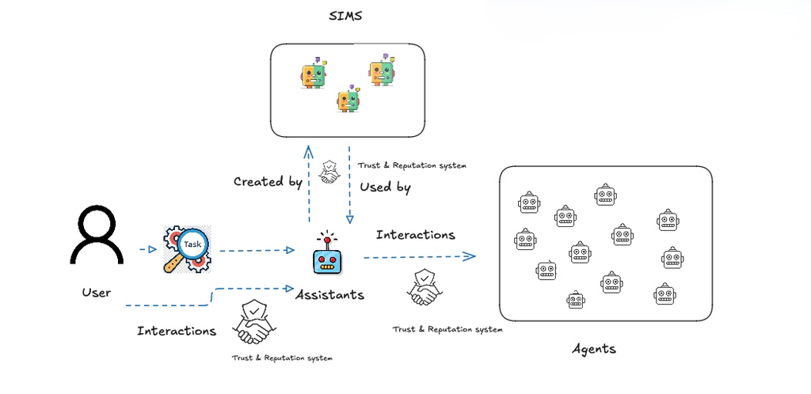

The ecosystem described above is inspired by Chirag's paper, but I have introduced a **Reputation/Trust System** that evaluates **Agents**, **Sims**, and **Assistants** based on their performance, reliability, and user satisfaction. Additionally, I have added a **Trust Metrics** layer that continuously monitors and updates the reputation of these components based on the user's interactions and feedback.